# L02 Modeling Fundamentals

Data Science 2 with R (STAT 301-2)

Author

Ryan Nguyen

## Overview

The goal of this lab is to review basic model syntax, diagnostics, model comparison, and prediction in R for linear models.

## Datasets

For the following exercises we will be using the `College` and `Auto` datasets from the `/data` subdirectory. Remember you can find codebooks for the data in the `ISLR` package; for example, `?ISLR::College`. May want to consider copying and using the `processed` data from L01 into the data folder.

```r
library(tidyverse)

auto <- read_csv("data/Auto.csv") %>%
  janitor::clean_names()

college <- read_csv("data/College.csv")%>%
  janitor::clean_names()

# cleaning up auto
auto_clean <- auto %>%
  mutate(horsepower = as.numeric(horsepower),
         origin = as_factor(origin),
         cylinders = as_factor(cylinders))
# saving auto as an rds
write_rds(auto_clean, "data/processed/auto_clean.rds")

college_clean <- college %>%
  janitor::clean_names() %>%
  mutate(private = as_factor(private))

write_rds(college_clean, "data/processed/college_clean.rds")
```

## Exercises

### Exercise 1

Run a linear model predicting `grad_rate` using the `College` data. Include `accept`, `outstate`, and `private` as predictors. Provide a summary of the model.

```r
model_1 <- lm(grad_rate ~ accept + outstate + private, college_clean)
summary(model_1)
```

```
Call:
lm(formula = grad_rate ~ accept + outstate + private, data = college_clean)

Residuals:
    Min      1Q  Median      3Q     Max
-47.661  -8.420   0.119   7.951  52.913

Coefficients:
              Estimate Std. Error t value Pr(>|t|)
(Intercept) 42.1374794  1.8831348  22.376  < 2e-16 ***
accept       0.0009662  0.0002459   3.929 9.28e-05 ***
outstate     0.0021691  0.0001582  13.714  < 2e-16 ***
privateNo   -4.6609526  1.6220657  -2.873  0.00417 **
---
Signif. codes:  0 '***' 0.001 '**' 0.01 '*' 0.05 '.' 0.1 ' ' 1

Residual standard error: 13.98 on 773 degrees of freedom
Multiple R-squared:  0.3402,    Adjusted R-squared:  0.3376
F-statistic: 132.8 on 3 and 773 DF,  p-value: < 2.2e-16
```

### Exercise 2

Expand on your model from Exercise 1. Include ALL possible interactions between `accept`, `outstate`, and `private`. Use a formula shortcut. Provide a summary of the model.

```r
model_2 <- lm(grad_rate ~ accept * outstate * private, college_clean)
summary(model_2)
```

```
Call:
lm(formula = grad_rate ~ accept * outstate * private, data = college_clean)

Residuals:
    Min      1Q  Median      3Q     Max
-47.447  -8.510  -0.071   8.020  52.513

Coefficients:
                            Estimate Std. Error t value Pr(>|t|)
(Intercept)                3.736e+01  2.764e+00  13.515  < 2e-16 ***
accept                     4.483e-03  1.604e-03   2.795  0.00532 **
outstate                   2.557e-03  2.328e-04  10.984  < 2e-16 ***
privateNo                  7.837e-01  5.667e+00   0.138  0.89005
accept:outstate           -2.531e-07  1.108e-07  -2.284  0.02264 *
accept:privateNo          -3.182e-03  1.901e-03  -1.674  0.09459 .
outstate:privateNo        -5.269e-04  7.713e-04  -0.683  0.49472
accept:outstate:privateNo  2.188e-07  1.655e-07   1.323  0.18639
---
Signif. codes:  0 '***' 0.001 '**' 0.01 '*' 0.05 '.' 0.1 ' ' 1

Residual standard error: 13.97 on 769 degrees of freedom
Multiple R-squared:  0.345, Adjusted R-squared:  0.339
F-statistic: 57.86 on 7 and 769 DF,  p-value: < 2.2e-16
```

### Exercise 3

Assess the residual and Q-Q plots for your models in Exercises 1 and 2. Are the assumptions met? Why or why not?

You can use base plots as shown in the book, or try challenging yourself to use `ggplot2` to create these plots.

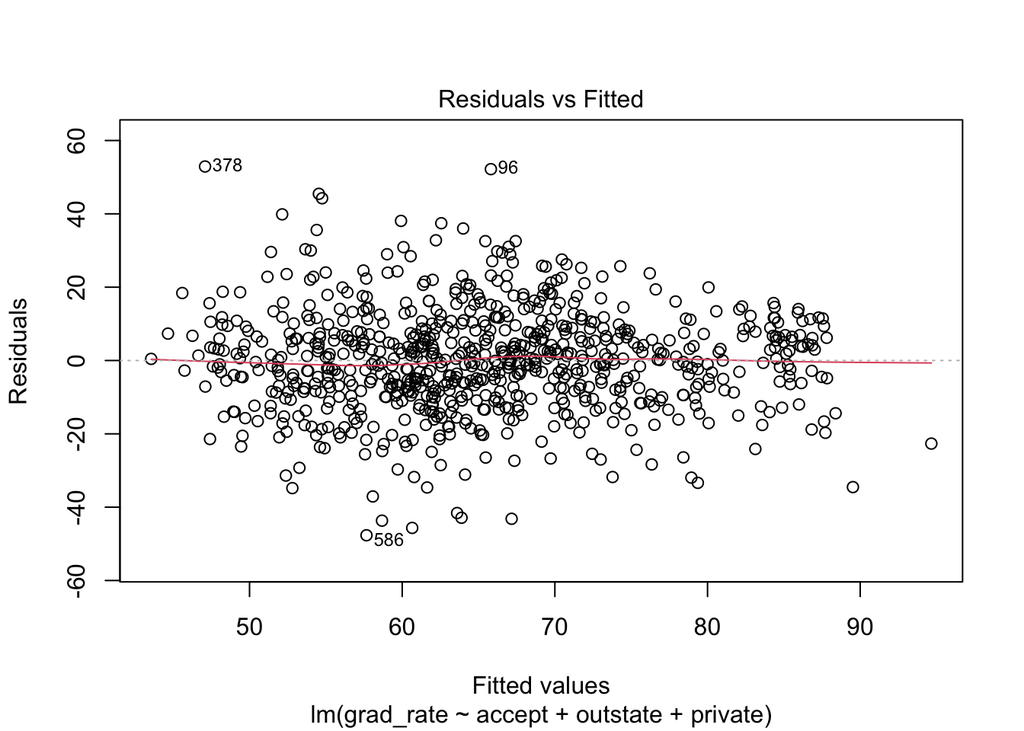

```r
plot(model_1, which = 1)
```

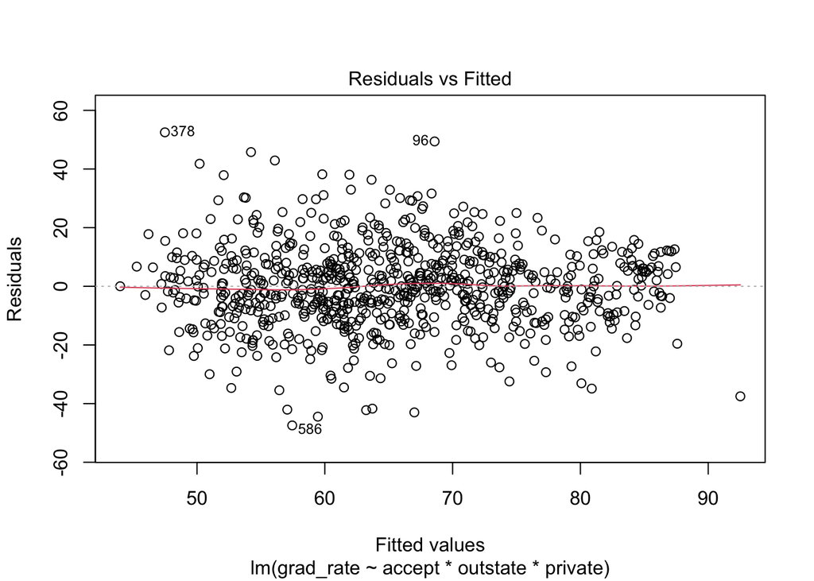

```r
plot(model_2, which = 1)
```

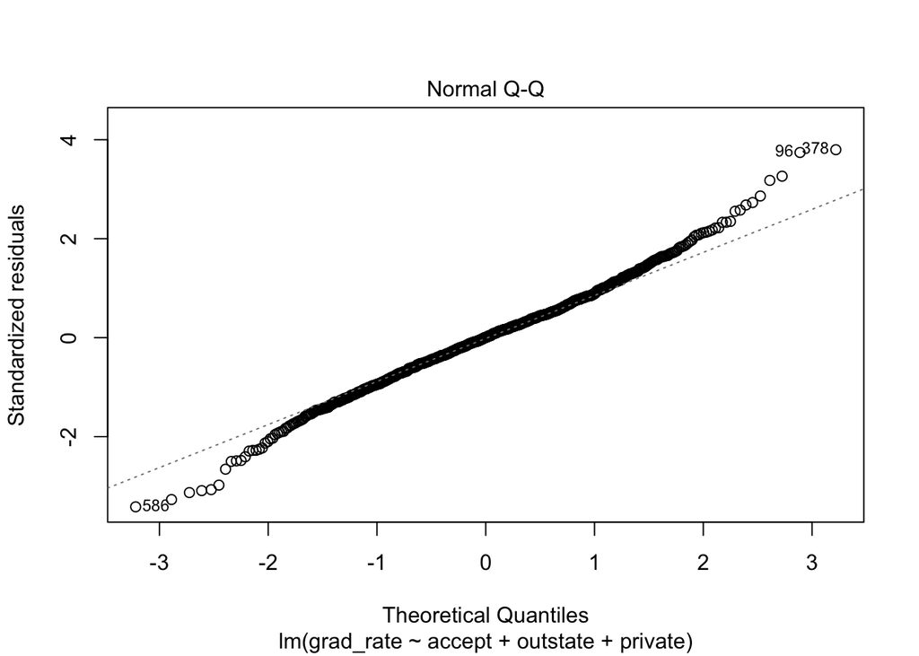

```r
plot(model_1, which = 2)
```

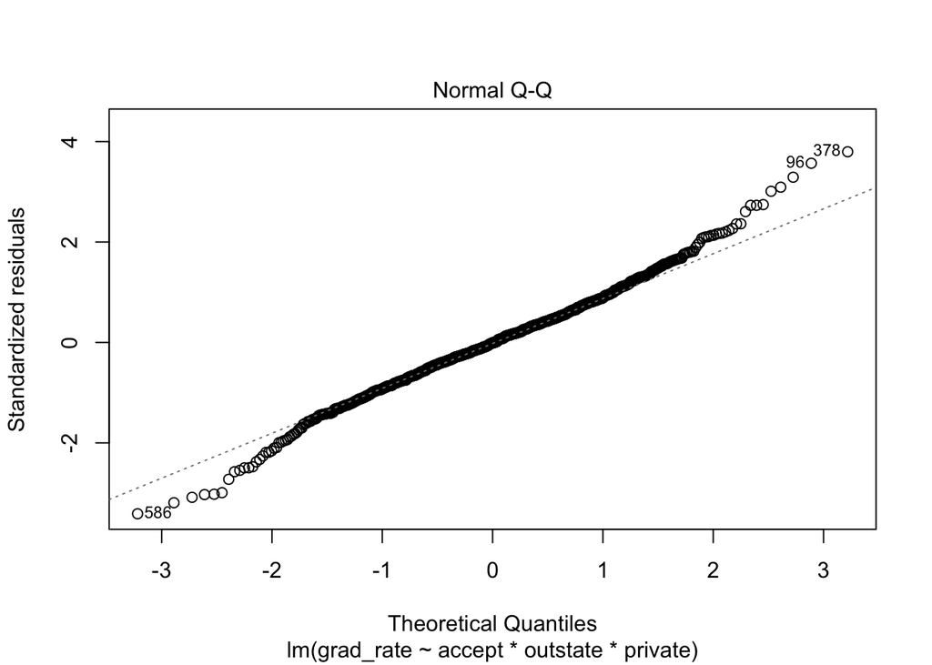

```r
plot(model_2, which = 2)
```

**ANSWER:** The assumption of constance variance is met since the variance of the residual appears to be close enough to being consistent for both models. Additionally, the normality assumption is met since it appears there is an approximate straight line for both models in the QQ plot, despite there being small deviations from both ends.

### Exercise 4

Use `anova()` to compare the model in Exercise 1 (without interactions) to the model in Exercise 2 (with interactions). Does including the interactions significantly improve the model? How do you know?

```r
anova(model_1, model_2)
```

```
Analysis of Variance Table

Model 1: grad_rate ~ accept + outstate + private
Model 2: grad_rate ~ accept * outstate * private
  Res.Df    RSS Df Sum of Sq      F Pr(>F)
1    773 151090
2    769 149986  4    1104.1 1.4152 0.2271
```

**ANSWERS:** Including the interactions do not significantly improve the model because the p-value is greater than 0.05, at 0.2271. The model without interactions is a subset of the model with interactions, and is better since the additional terms do not do anything significant.

### Exercise 5

Use the `predict()` function (with the “better” model) to predict the graduation rate of a private university with 5,000 accepted applications and $6,000 out-of-state tuition.

```r
new_grad_rate <- data.frame(private = "Yes", accept = 5000, outstate = 6000)
predict(model_1, new_grad_rate)
```

```
       1
59.98324
```

**ANSWER:** Using the `predict` function with `model_1`, we found that the graduation rate of a private university with 5,000 accepted applications and $6,000 out-of-state tuition would be predicted to be 59.98.

### Exercise 6

Begin by spliting the `Auto` dataset into training and test datasets.

Using the `training` dataset, find at least 3 variables that have a relationship with `mpg` and build a linear model with those variables as predictors (simple additive model no interaction or transformations).

*Hint: consider correlation and visual plots with mpg*

```r
# splitting auto data set into training and test
library(tidymodels)

set.seed(1234)

auto_split <- initial_split(auto_clean, prob = 0.8)

auto_training <- training(auto_split)
auto_testing <- testing(auto_split)
```

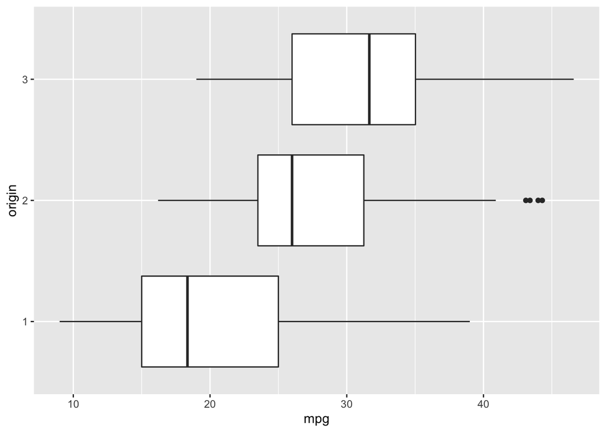

```r
# finding variables with relationships with mpg
auto_training %>%
  ggplot(aes(x = mpg, y = origin)) +
  geom_boxplot()
```

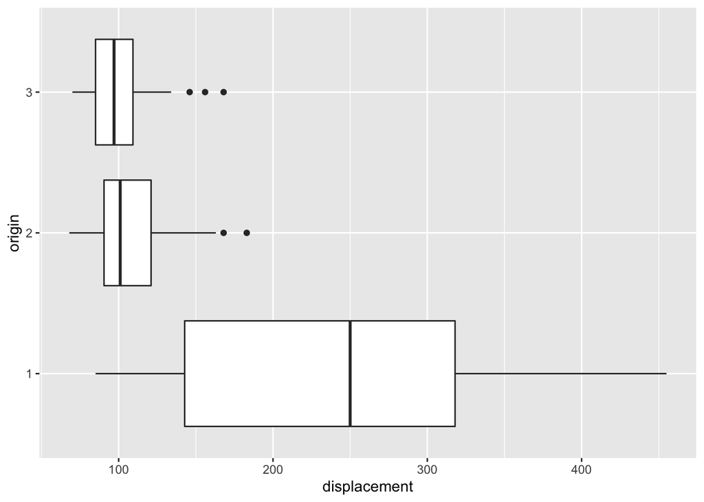

```r
auto_training %>%
  ggplot(aes(x = displacement, y = origin)) +
  geom_boxplot()
```

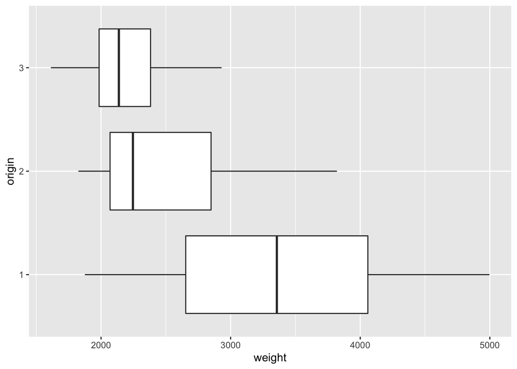

```r
auto_training %>%
  ggplot(aes(x = weight, y = origin)) +
  geom_boxplot()
```

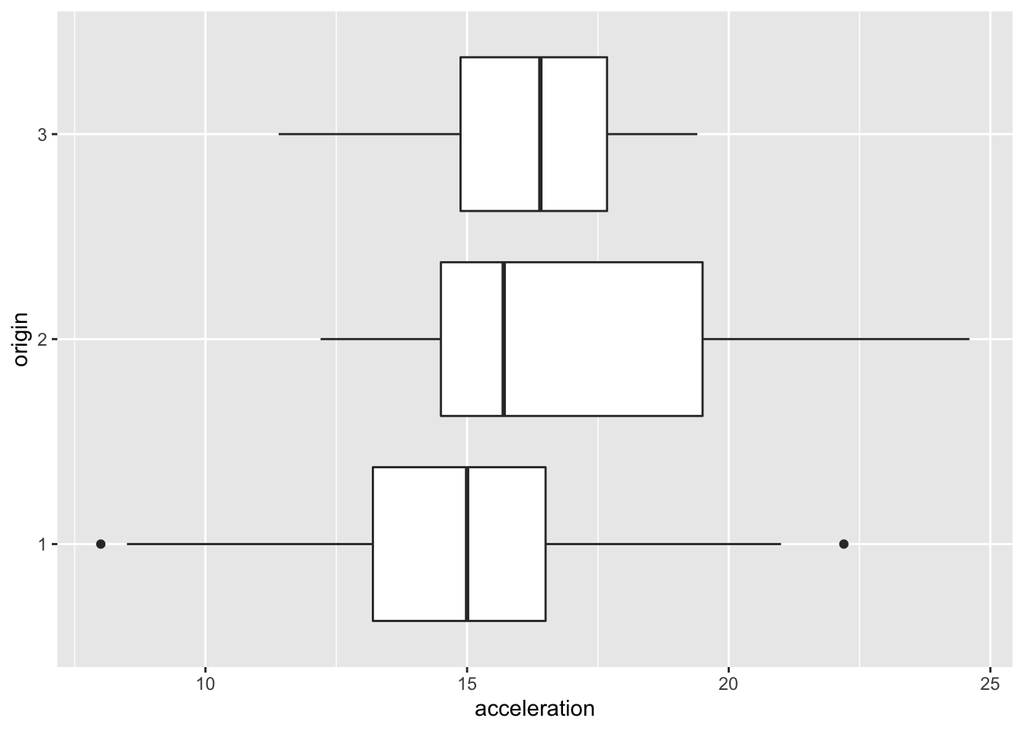

```r
auto_training %>%
  ggplot(aes(x = acceleration, y = origin)) +
  geom_boxplot()
```

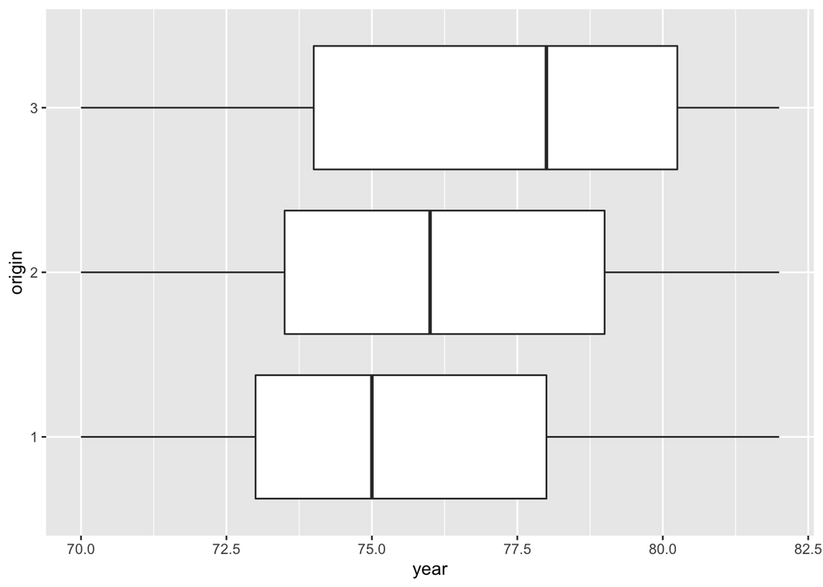

```r
auto_training %>%
  ggplot(aes(x = year, y = origin)) +
  geom_boxplot()
```

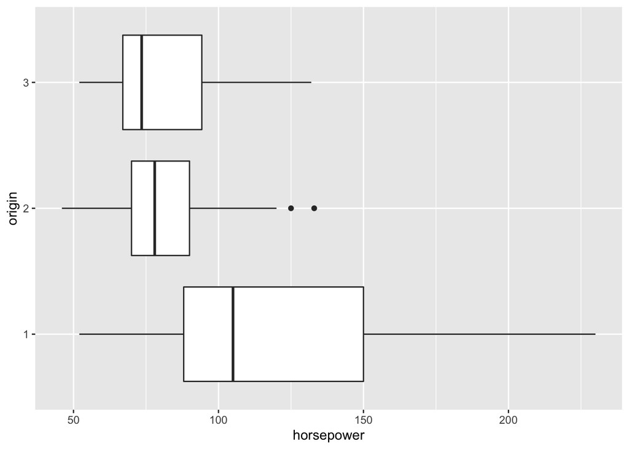

```r
auto_training %>%
  ggplot(aes(x = horsepower, y = origin)) +
  geom_boxplot()
```

```r
# building model with horsepower, displacement, and weight as predictors
model_6 <- lm(mpg ~ horsepower + displacement + weight, auto_training)
summary(model_6)
```

```
Call:
lm(formula = mpg ~ horsepower + displacement + weight, data = auto_training)

Residuals:
   Min     1Q Median     3Q    Max
-9.053 -2.807 -0.366  2.239 15.948

Coefficients:
               Estimate Std. Error t value Pr(>|t|)
(Intercept)  45.4073034  1.3388225  33.916  < 2e-16 ***
horsepower   -0.0484167  0.0147142  -3.290  0.00112 **
displacement -0.0064608  0.0073595  -0.878  0.38074
weight       -0.0052383  0.0008134  -6.440 4.99e-10 ***
---
Signif. codes:  0 '***' 0.001 '**' 0.01 '*' 0.05 '.' 0.1 ' ' 1

Residual standard error: 4.214 on 288 degrees of freedom
  (5 observations deleted due to missingness)
Multiple R-squared:  0.725, Adjusted R-squared:  0.7221
F-statistic: 253.1 on 3 and 288 DF,  p-value: < 2.2e-16
```

### Exercise 7

Assess the residual and Q-Q plots for your model in Exercise 6. Are the assumptions met? They most likely are not. If they are not met, perform an appropriate transformation. Store this new model and check the assumptions again until you have an “acceptable” model.

*Hint: should we transform x or y? Look at the relationship of mpg with the variables you chose.*

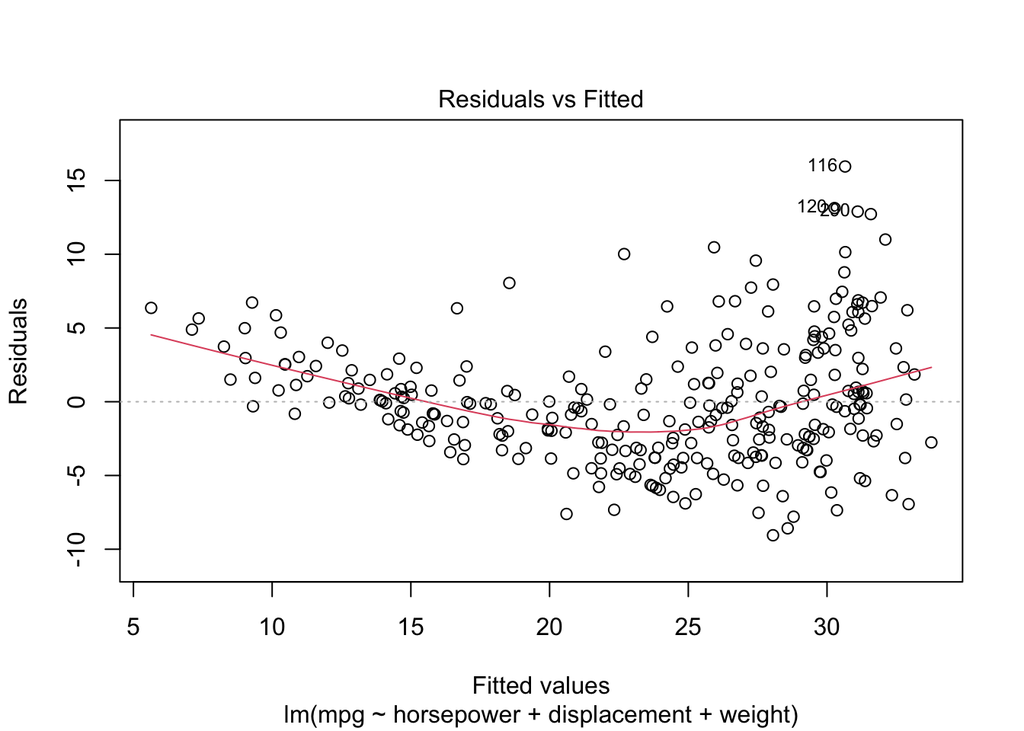

```r
plot(model_6, which = 1)
```

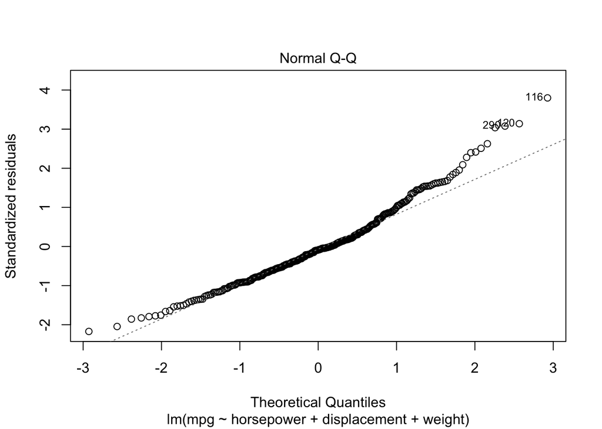

```r
plot(model_6, which = 2)
```

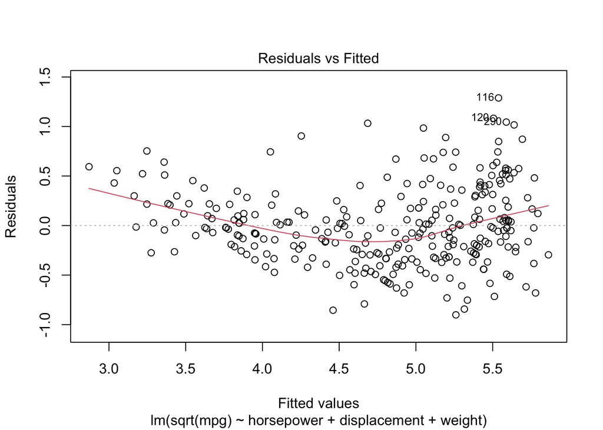

```r
model_7 <-lm(sqrt(mpg) ~ horsepower + displacement + weight, auto_training)
plot(model_7, which = 1)
```

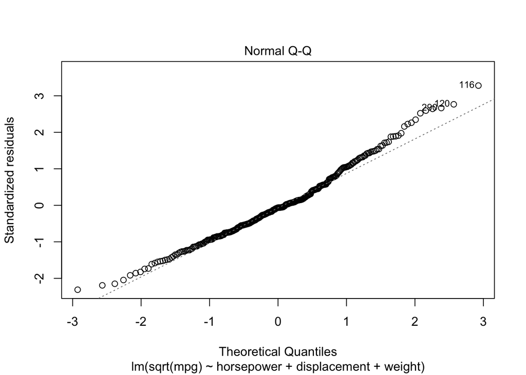

```r
plot(model_7, which = 2)
```

### Exercise 8

Assess and compare the model performance between the model in Exercise 6 and Exercise 7 using RMSE.

```r
modelr:: rmse(model_6, auto_testing)
```

```
[1] 4.348253
```

```r
pred_log <- (predict(model_7, auto_testing))^(2)
error <- auto_testing$mpg - pred_log
sqrt(mean(error^2))
```

```
[1] 4.170796
```

**ANSWER:** While comparing the models from exercise 6 and exercise 7, model from exercise 7 is the best since the RMSE is lower.

### Exercise 9

Build any linear model that performs “better” than your models in Exercise 7 and 8. Performance metric is up to you.

*If you cannot find a better model, you should show a table/summary of the models you tried with their corresponding performance metric.*

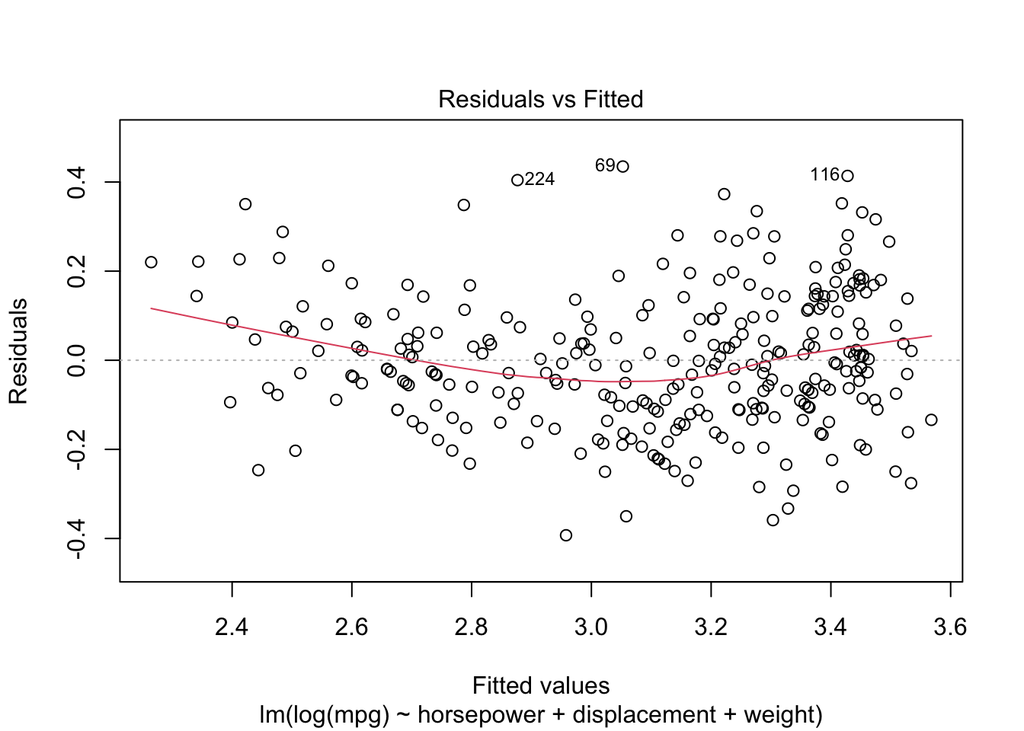

```r
model_9 <- lm(log(mpg) ~ horsepower + displacement + weight, auto_training)
plot(model_9, which = 1)
```

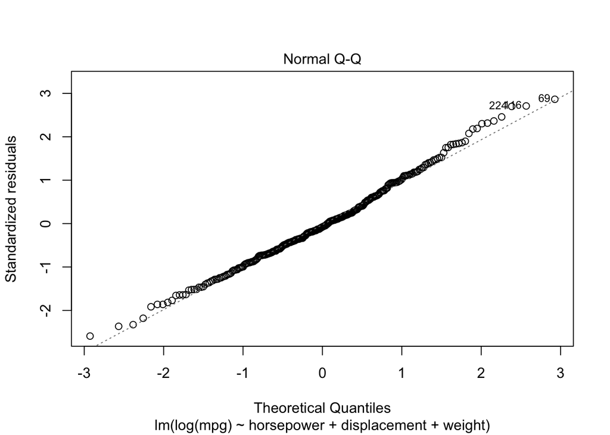

```r
plot(model_9, which = 2)
```

```r
pred_9 <- exp(predict(model_9, auto_testing))
error_9 <- auto_testing$mpg - pred_9
sqrt(mean(error_9^2))
```

```
[1] 4.088746
```

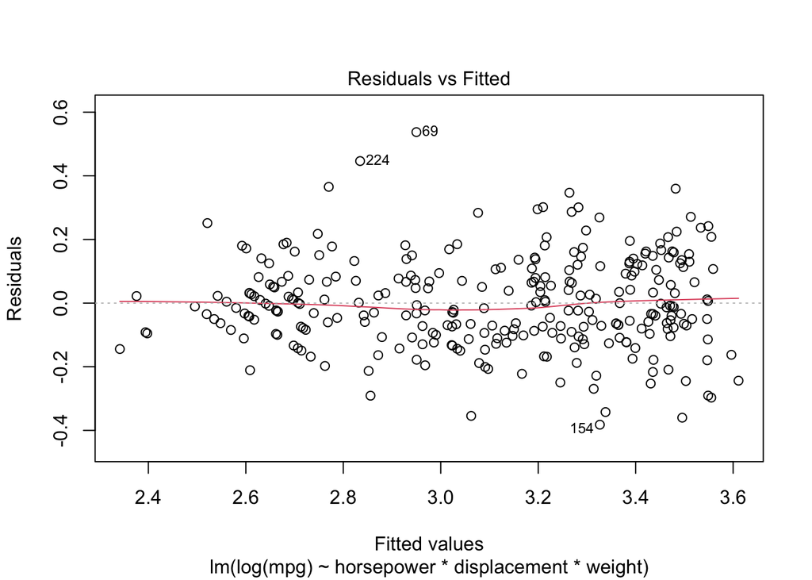

```r
model_10 <- lm(log(mpg) ~ horsepower * displacement * weight, auto_training)
plot(model_10, which = 1)
```

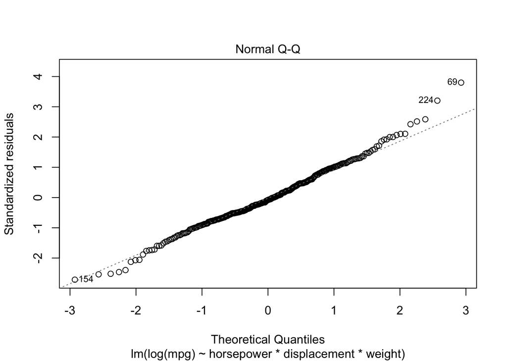

```r
plot(model_10, which = 2)
```

```r
pred_log_10 <- exp(predict(model_10, auto_testing))
error_10 <- auto_testing$mpg - pred_log_10
sqrt(mean(error_10^2))
```

```
[1] 4.115056
```